# Copepod Markdown

2022-10-25

# Notes

main food source for larval fishes, delta smelt 4 sampling locations, 4 different habitat types, maybe one habitat type is better calculated growth rates for copepods counted microzoo plankton samples, available food sources (others have studied chlorophyll only phytoplankton) This will include all microplankton

two samples per location, discarded 2 ended with 6 samples

## variables

samp_ev = location name exp IC - intial controls

sa - short axis la - long axis wi - width

ignore pres_fact, vol_set_ml, n_bugs, time_d

## treatments

final - sample bottles after 24 hours treatments - sample water plus copepods eat for 24 hours initial

3 replicates per sample

tot_vol_um3 tot_biomass_pgC

## already done

1. calculate biomass

## goal

what kind of food was available and how does that compare to growth rates?

relationship between growth rates and biomass

reproduction rate:

## what needs to be done

ctbm_grptyp_with_site organisms

consolidate each organism into small and large, by biomass?

feeding rates - how much of the food is in the sample did the copepods eat

clearance rate - volume of water multiplied by natural log …

# Analysis

## Read in Data

```r
library(readxl)
headers100 <- read.csv(file="100xHeaders.csv")
headers400 <- read.csv("400xHeaders.csv")
voll_mass <- read.csv("Clean Data/vollbio_all_no0.csv")
RawcountComb <- read.csv("Clean Data/RawcountComb.csv")
headersComb <- read.csv("Clean Data/headersComb.csv")
volbio_all_no0 <- read.csv("Clean Data/vollbio_all_no0.csv")
ct_bmn_fin <- read.csv("Clean Data/ct_bmn_fin.csv")

# combine these with a key
#Rawcount400 <- read_excel("400x_RawCount_R.xlsx")
#Rawcount100 <- read_excel("100x_RawCount_R.xlsx")
#Rawcount100$zoom = 100
#Rawcount400$zoom = 400
#RawcountComb <- rbind(Rawcount100, Rawcount400)

#headers100$zoom = 100
#headers400$zoom = 400
#headersComb <- rbind(headers100, headers400)
```

## Microplankton ambient analysis

### Counts by groups

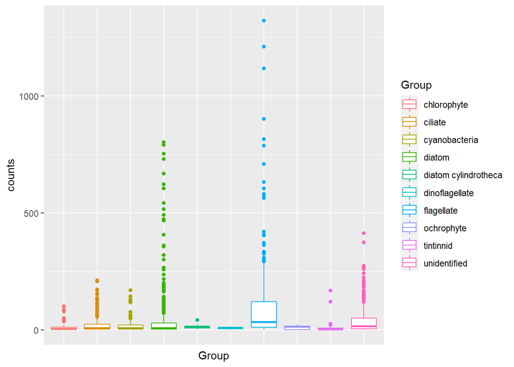

```r
library(ggplot2)
#unique(volbio_all_no0$Group)
# about 10 groups already
ggplot(volbio_all_no0, aes(Group, counts, color=Group))+
  geom_boxplot()+
  theme(axis.ticks.x = element_blank(),
        axis.text.x = element_blank())
```

### biomass by groups

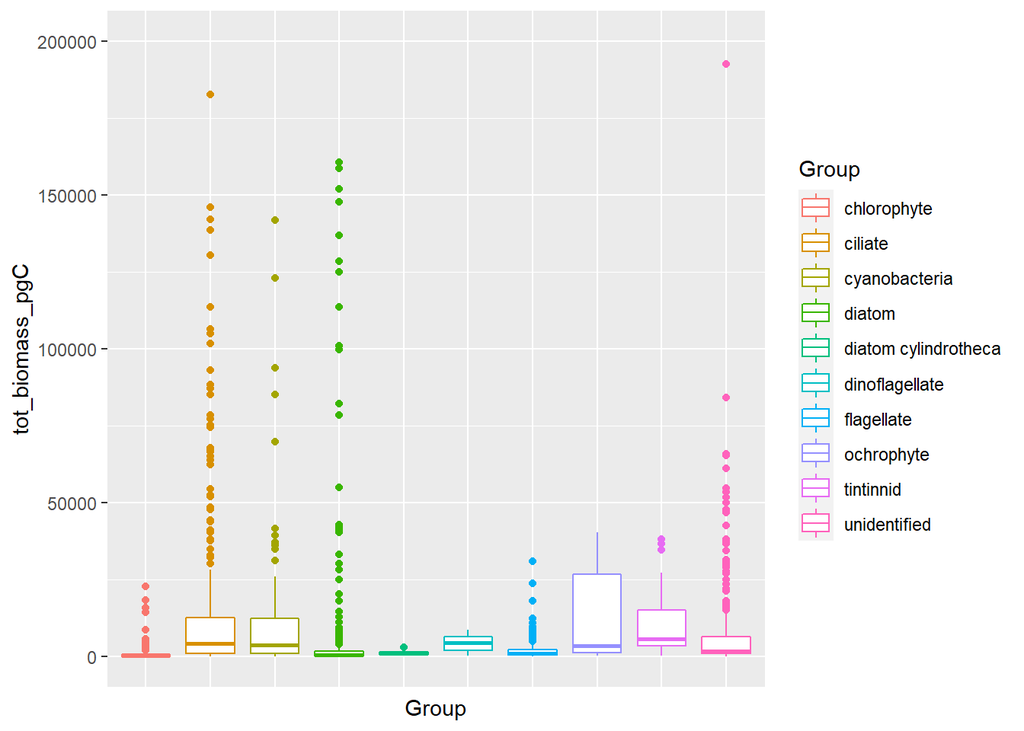

```r
ggplot(volbio_all_no0, aes(Group, tot_biomass_pgC, color=Group))+
  geom_boxplot()+
  theme(axis.ticks.x = element_blank(),
        axis.text.x = element_blank()) +
    coord_cartesian(ylim = c(0, 200000))
```

```r
# ran this zoomed in which doesnt show top outliers but better representation of true data
```

### Counts by groups percent of each sampling event

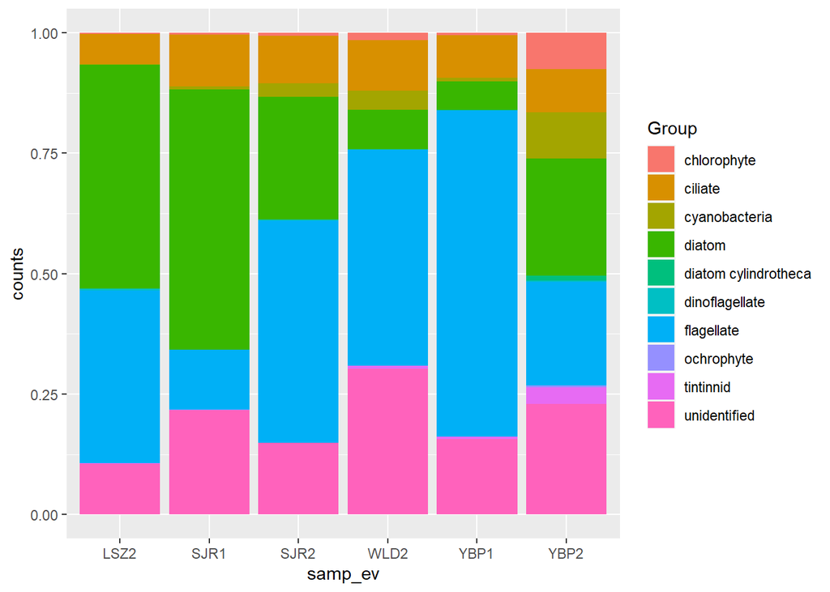

```r
ggplot(volbio_all_no0, aes(fill=Group, y=counts, x= samp_ev))+
  geom_bar(position='fill', stat='identity')
```

```r
# also try postion = 'stack' for a stacked barchart
```

### Biomass by groups percent of each sampling event

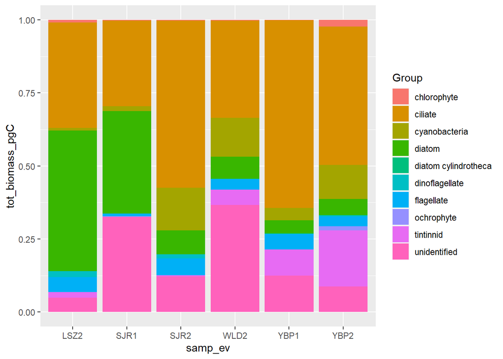

```r
ggplot(volbio_all_no0, aes(fill=Group, y=tot_biomass_pgC, x= samp_ev))+
  geom_bar(position='fill', stat='identity')
```

### Biomass by groups percent of each experimental sample

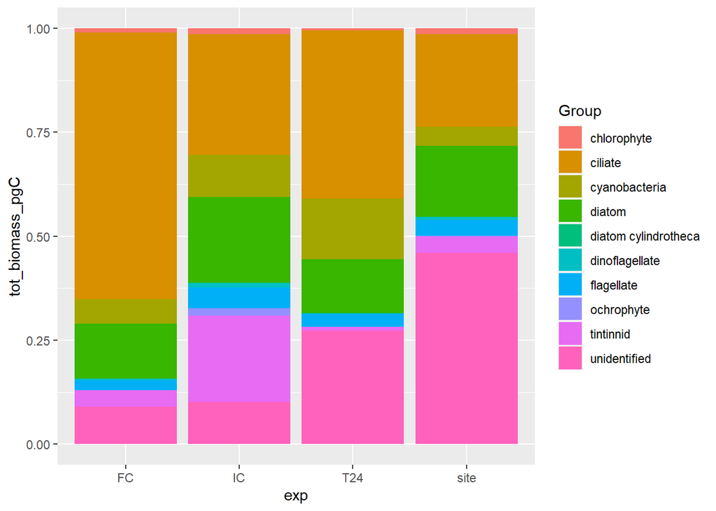

```r
# sort by factoring to get desired ordering
volbio_all_no0$exp <- factor(volbio_all_no0$exp, levels = c("FC", "IC","T24", "site"))

ggplot(volbio_all_no0, aes(fill=Group, y=tot_biomass_pgC, x= exp))+
  geom_bar(position='fill', stat='identity')
```

*Note: maybe we can remove unidentified for this*

#### percentage

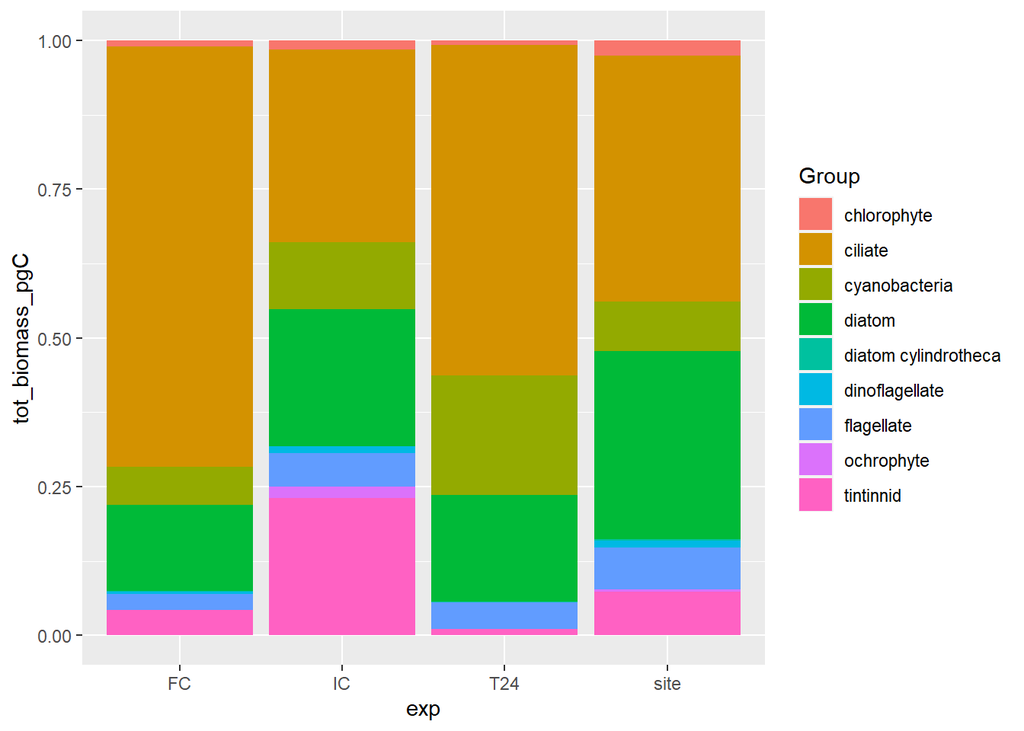

```r
# this version has no unidentified
volbio_all_id <- subset(volbio_all_no0, Group!="unidentified")

ggplot(volbio_all_id, aes(fill=Group, y=tot_biomass_pgC, x= exp))+
  geom_bar(position='fill', stat='identity')
```

#### stacked

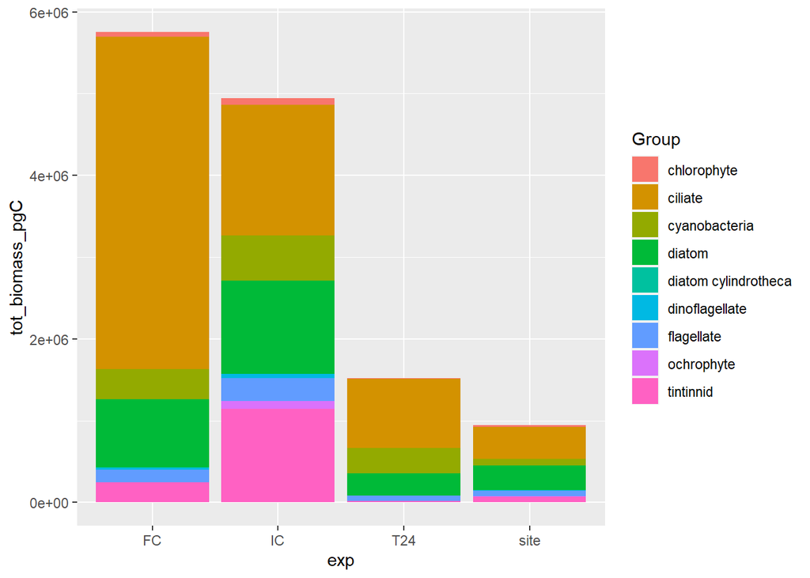

```r
# this version has no unidentified
volbio_all_id <- subset(volbio_all_no0, Group!="unidentified")

ggplot(volbio_all_id, aes(fill=Group, y=tot_biomass_pgC, x= exp))+
  geom_bar(position='stack', stat='identity')
```

### Counts by groups percent of each experimental sample

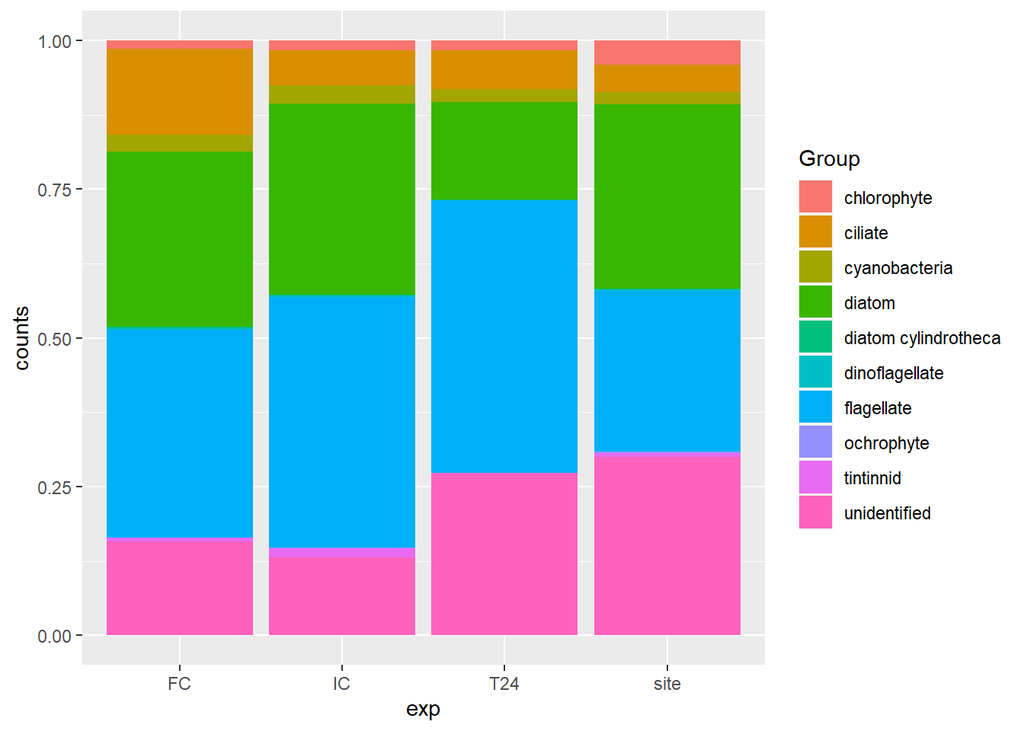

```r
ggplot(volbio_all_no0, aes(fill=Group, y=counts, x= exp))+
  geom_bar(position='fill', stat='identity')
```

#### percentage

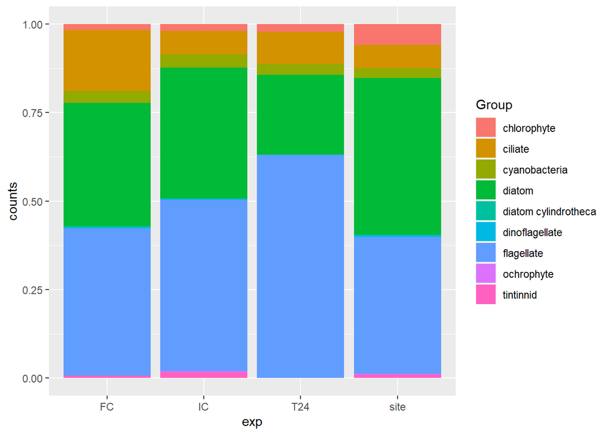

```r
ggplot(volbio_all_id, aes(fill=Group, y=counts, x= exp))+
  geom_bar(position='fill', stat='identity')
```

#### stacked

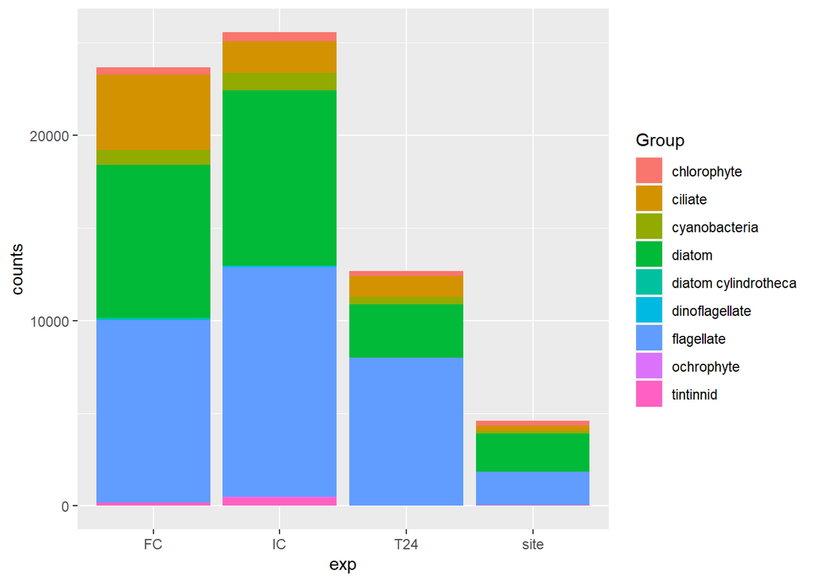

```r
ggplot(volbio_all_id, aes(fill=Group, y=counts, x= exp))+
  geom_bar(position='stack', stat='identity')
```

### Counts and biomass by groups by sampling event by experimental sample

*Could potentially do this by doing a grid of experimental samples*

## Aggregate organism categories

There is just too much information to display here

# Other graphs of organisms by counts by sampling event separate graphs

```r
# Split into sampling events
LSZ2 = subset(volbio_all_no0, samp_ev == "LSZ2")
WLD2 = subset(volbio_all_no0, samp_ev == "WLD2")
YBP1 = subset(volbio_all_no0, samp_ev == "YBP1")
YBP2 = subset(volbio_all_no0, samp_ev == "YBP2")
SJR1 = subset(volbio_all_no0, samp_ev == "SJR1")
SJR2 = subset(volbio_all_no0, samp_ev == "SJR2")
```

#### LSZ2

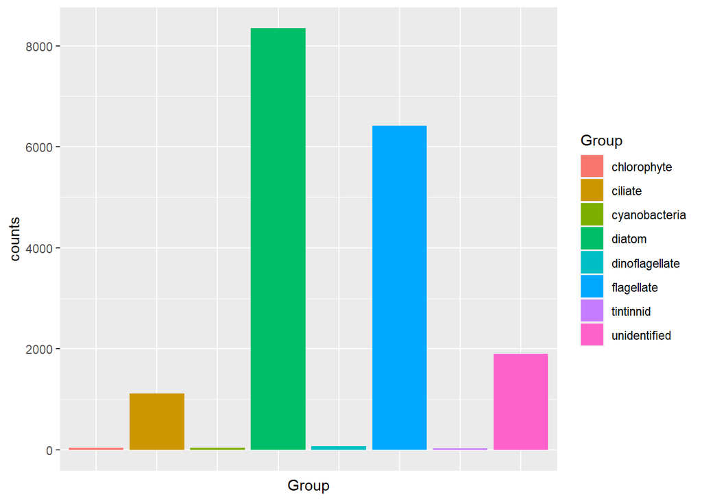

```r
ggplot(LSZ2, aes(fill=Group, y=counts, x= Group))+
  geom_bar(stat='identity')+
  theme(axis.ticks.x = element_blank(),axis.text.x = element_blank())
```

```r
# also try postion = 'stack' for a stacked barchart
```

#### WLD2

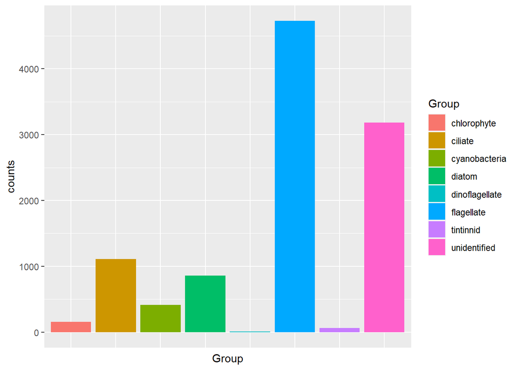

```r
ggplot(WLD2, aes(fill=Group, y=counts, x= Group))+
  geom_bar(stat='identity')+
  theme(axis.ticks.x = element_blank(),axis.text.x = element_blank())
```

```r
# also try postion = 'stack' for a stacked barchart
```

#### YBP1

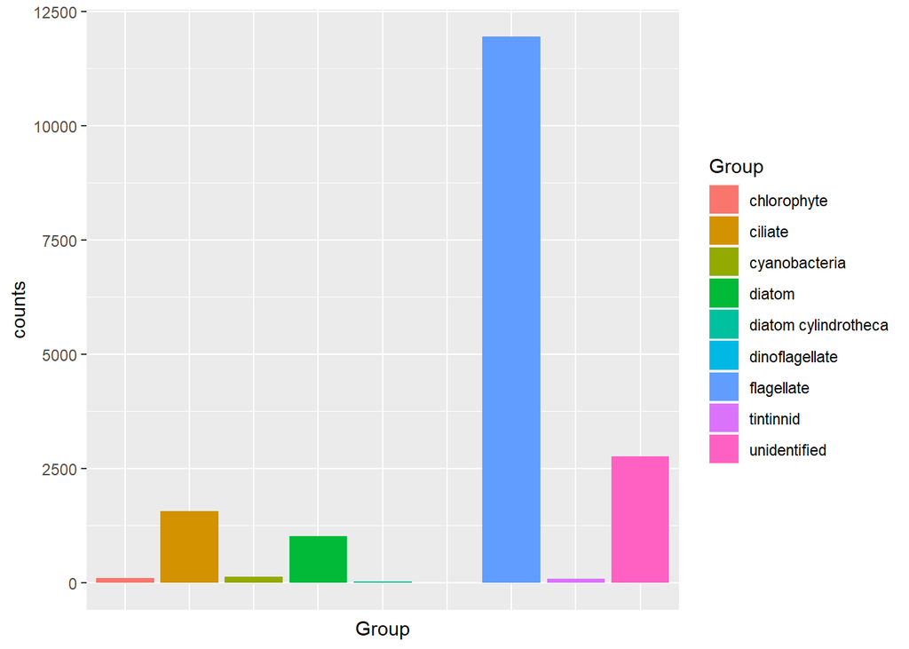

```r
ggplot(YBP1, aes(fill=Group, y=counts, x= Group))+
  geom_bar(stat='identity')+
  theme(axis.ticks.x = element_blank(),axis.text.x = element_blank())
```

```r
# also try postion = 'stack' for a stacked barchart
```

#### YBP2

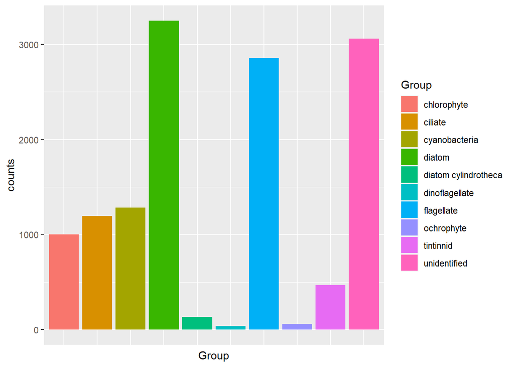

```r
ggplot(YBP2, aes(fill=Group, y=counts, x= Group))+
  geom_bar(stat='identity')+
  theme(axis.ticks.x = element_blank(),axis.text.x = element_blank())
```

```r
# also try postion = 'stack' for a stacked barchart
```

#### SJR1

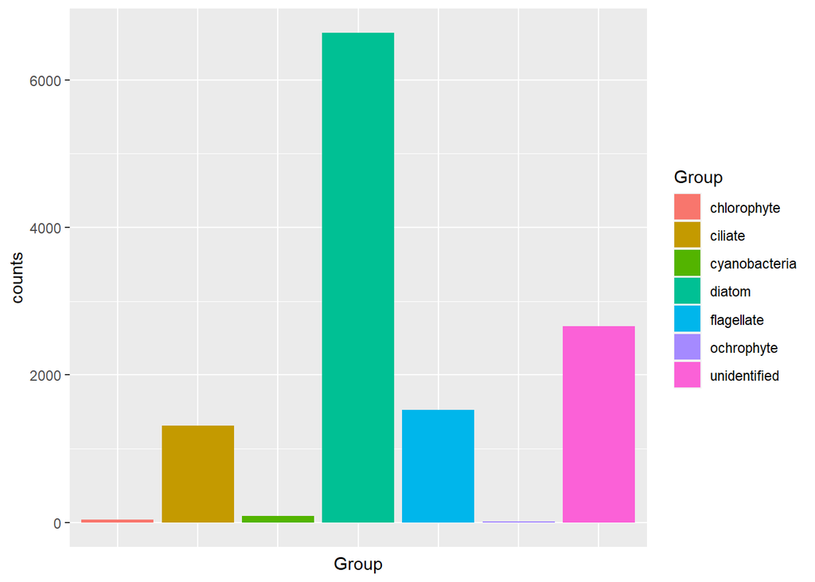

```r
ggplot(SJR1, aes(fill=Group, y=counts, x= Group))+
  geom_bar(stat='identity')+
  theme(axis.ticks.x = element_blank(),axis.text.x = element_blank())
```

```r
# also try postion = 'stack' for a stacked barchart
```

#### SJR2

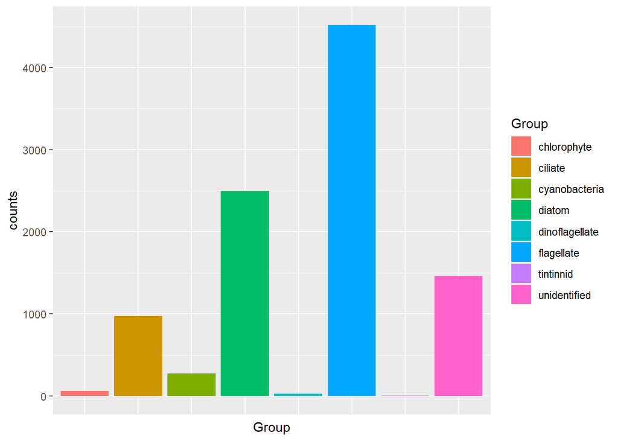

```r
ggplot(SJR2, aes(fill=Group, y=counts, x= Group))+
  geom_bar(stat='identity')+
  theme(axis.ticks.x = element_blank(),axis.text.x = element_blank())
```

```r
# also try postion = 'stack' for a stacked barchart
```

# with the ct_bmn_fin data

```r
# Split into sampling events
LSZ2 = subset(ct_bmn_fin, samp_ev == "LSZ2")
WLD2 = subset(ct_bmn_fin, samp_ev == "WLD2")
YBP1 = subset(ct_bmn_fin, samp_ev == "YBP1")
YBP2 = subset(ct_bmn_fin, samp_ev == "YBP2")
SJR1 = subset(ct_bmn_fin, samp_ev == "SJR1")
SJR2 = subset(ct_bmn_fin, samp_ev == "SJR2")
```

## LSZ2 example with log scale

```r
p1 <- ggplot(LSZ2, aes(fill=Group, y=log_mean_ct, x= reorder(Group, -log_mean_ct)))+
  geom_boxplot() + theme(axis.ticks.x = element_blank(),axis.text.x = element_blank())

# also try postion = 'stack' for a stacked barchart
```

## WLD2 example with log scale

```r
p2 <- ggplot(WLD2, aes(fill=Group, y=log_mean_ct, x= reorder(Group, -log_mean_ct)))+
  geom_boxplot() + theme(axis.ticks.x = element_blank(),axis.text.x = element_blank())

# also try postion = 'stack' for a stacked barchart
```

## YBP1 example with log scale

```r
p3 <- ggplot(YBP1, aes(fill=Group, y=log_mean_ct, x= reorder(Group, -log_mean_ct)))+
  geom_boxplot() + theme(axis.ticks.x = element_blank(),axis.text.x = element_blank())

# also try postion = 'stack' for a stacked barchart
```

## YBP2 example with log scale

```r
p4 <- ggplot(YBP2, aes(fill=Group, y=log_mean_ct, x= reorder(Group, -log_mean_ct)))+
  geom_boxplot() + theme(axis.ticks.x = element_blank(),axis.text.x = element_blank())

# also try postion = 'stack' for a stacked barchart
```

## SJR1 example with log scale

```r
p5 <- ggplot(SJR1, aes(fill=Group, y=log_mean_ct, x= reorder(Group, -log_mean_ct)))+
  geom_boxplot() + theme(axis.ticks.x = element_blank(),axis.text.x = element_blank())

# also try postion = 'stack' for a stacked barchart
```

# SJR2

```r
p6 <- ggplot(SJR2, aes(fill=Group, y=log_mean_ct, x= reorder(Group, -log_mean_ct)))+
  geom_boxplot() + theme(axis.ticks.x = element_blank(),axis.text.x = element_blank())

# also try postion = 'stack' for a stacked barchart
```

# all together

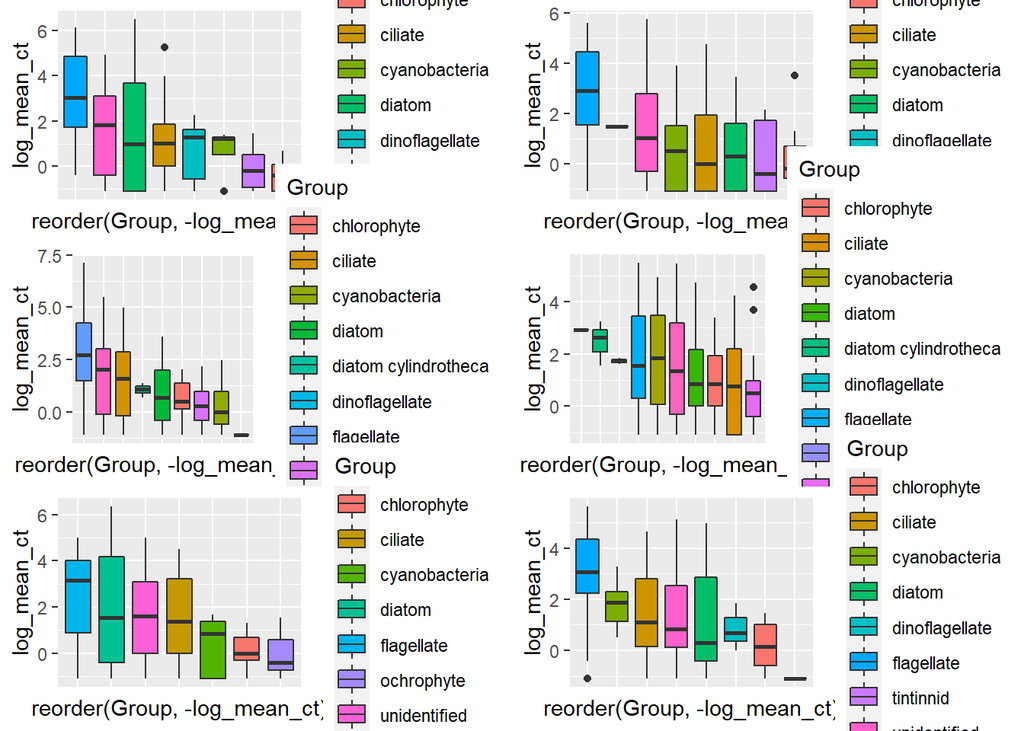

```r
library(gridExtra)
grid.arrange(p1,p2,p3,p4,p5,p6, nrow=3)
```